# パーマーステーションのペンギンたち 4 分析例編

@bob3bob3

2024-01-20

palmerpenguinsは機械学習や統計解析、可視化のデモデータとして整備されたデータセットです。

Rでは[palmerpenguinsパッケージ](https://allisonhorst.github.io/palmerpenguins/)をインストールすれば使えます。

[素のcsvファイル](https://raw.githubusercontent.com/allisonhorst/palmerpenguins/main/inst/extdata/penguins.csv)も配布されているのでPythonなど他のツールでも使えます。

過去3回にわたってその内容や使い方を紹介してきました。

伝えたいこととしては「ペンギンデータは使いやすいからみんな使うといいよ！」ということだけです。

今回はその最終回（たぶん）になる分析例編です。

[パーマーステーションのペンギンたち1](https://speakerdeck.com/bob3bob3/tokoy-dot-r-number-99-pamasutesiyonfalsepengintati-number-1)

[パーマーステーションのペンギンたち2 データクリーニング編](https://speakerdeck.com/bob3bob3/tokyor-number-101-pamasutesiyonnopengintati2-detakuriningubian)

[パーマーステーションのペンギンたち3 探索的データ分析(EDA)編](https://speakerdeck.com/bob3bob3/pamasutesiyonnopengintati-number-3-tan-suo-de-detafen-xi-eda-bian)

今回はpalmerpenguinsを使って、以下の手法を試してみましょう。

- 相関係数
- 回帰モデル
- 判別モデル
- 次元縮約（次元削減）
- クラスタリング

まずはいつものパッケージを呼び出します。

```r
library(conflicted)
library(tidyverse)
library(palmerpenguins)
data(penguins)
```

`summaryTools`でデータの概要を把握します。

```r
library(summarytools)
penguins |>
  dfSummary(
    plain.ascii  = FALSE,
    style        = "grid",
    graph.magnif = 0.85,
    varnumbers = FALSE,
    valid.col    = FALSE,
    tmp.img.dir  = "/tmp"
    )
```

```
## temporary images written to 'C:\tmp'
```

| Variable | Stats / Values | Freqs (% of Valid) | Graph | text.graph | Missing |
| --- | --- | --- | --- | --- | --- |
| species [factor] | 1. Adelie 2. Chinstrap 3. Gentoo | \152 (44.2%) 68 (19.8%) \124 (36.0%) |  |  | 0 (0.0%) |
| island [factor] | 1. Biscoe 2. Dream 3. Torgersen | \168 (48.8%) \124 (36.0%) 52 (15.1%) |  |  | 0 (0.0%) |
| bill_length_mm [numeric] | Mean (sd) : 43.9 (5.5) min < med < max: 32.1 < 44.5 < 59.6 IQR (CV) : 9.3 (0.1) | 164 distinct values |  |  | 2 (0.6%) |
| bill_depth_mm [numeric] | Mean (sd) : 17.2 (2) min < med < max: 13.1 < 17.3 < 21.5 IQR (CV) : 3.1 (0.1) | 80 distinct values |  |  | 2 (0.6%) |
| flipper_length_mm [integer] | Mean (sd) : 200.9 (14.1) min < med < max: 172 < 197 < 231 IQR (CV) : 23 (0.1) | 55 distinct values |  |  | 2 (0.6%) |
| body_mass_g [integer] | Mean (sd) : 4201.8 (802) min < med < max: 2700 < 4050 < 6300 IQR (CV) : 1200 (0.2) | 94 distinct values |  |  | 2 (0.6%) |
| sex [factor] | 1. female 2. male | \165 (49.5%) \168 (50.5%) |  |  | 11 (3.2%) |
| year [integer] | Mean (sd) : 2008 (0.8) min < med < max: 2007 < 2008 < 2009 IQR (CV) : 2 (0) | 2007 : 110 (32.0%) 2008 : 114 (33.1%) 2009 : 120 (34.9%) |  |  | 0 (0.0%) |

`ggpairs`でざっとデータ全体を見渡しましょう。

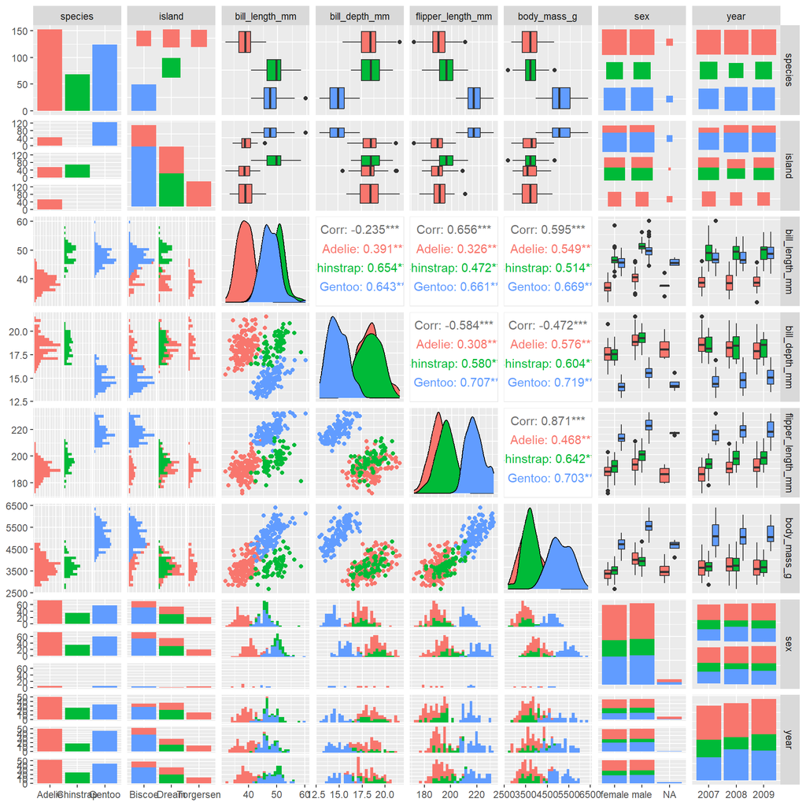

```r
library(GGally)
penguins |>
  mutate(year = factor(year)) |>
  ggpairs(aes(color = species))
```

## 相関係数

先ほどの図で相関係数を確認してみると、クチバシの高さ（深さ）と体重、ひれの長さが負の相関にあることが分かります。

しかし、種類ごとの相関は正の相関です。

しかしそんなことがあるでしょうか？

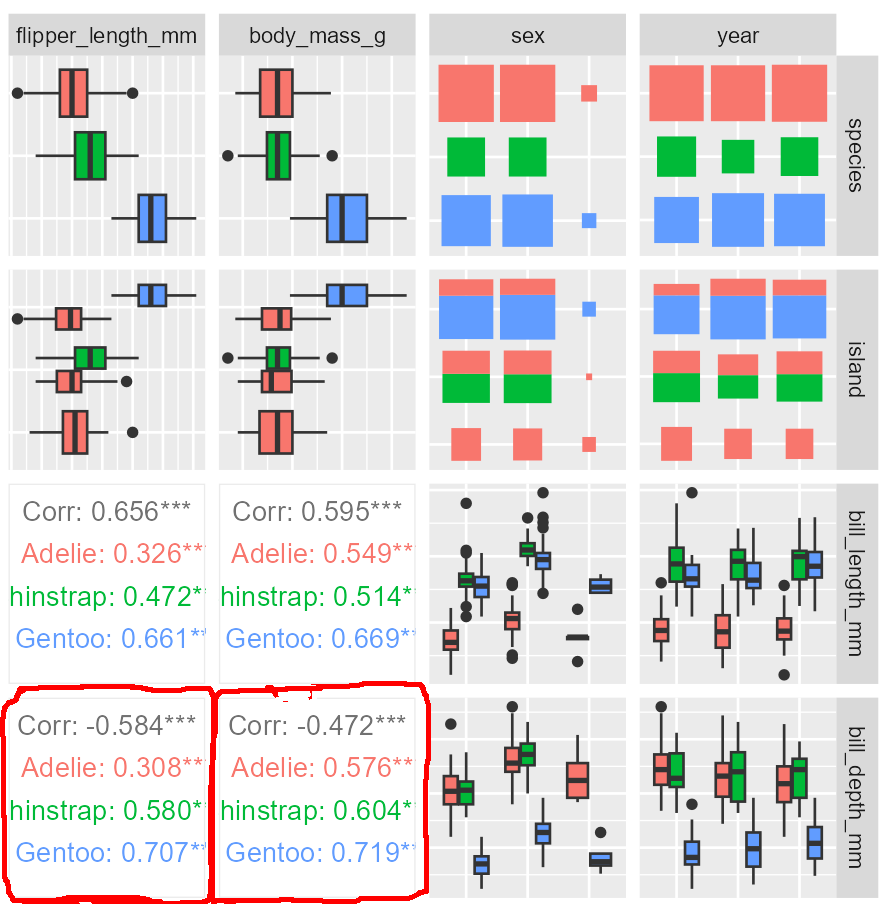

散布図で確認します。

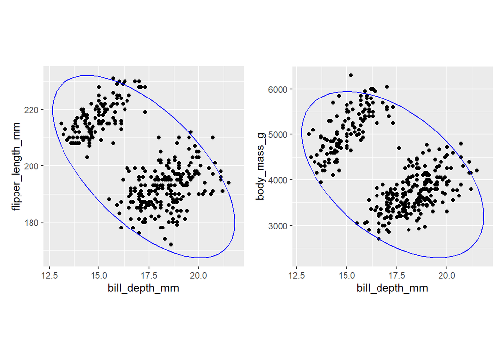

```r
library(patchwork)

p1 <- penguins |>
  ggplot(aes(x = bill_depth_mm, y = flipper_length_mm)) +
  geom_point() +
  stat_ellipse(color = "blue") +
  theme(aspect.ratio = 1)

p2 <- penguins |>
  ggplot(aes(x = bill_depth_mm, y = body_mass_g)) +
  geom_point() +
  stat_ellipse(color = "blue") +
  theme(aspect.ratio = 1)

p1 + p2
```

確かに全体では負の相関になっていますが、なんだかおかしな分布ですね？

ペンギンの種類で色を付けてみます。

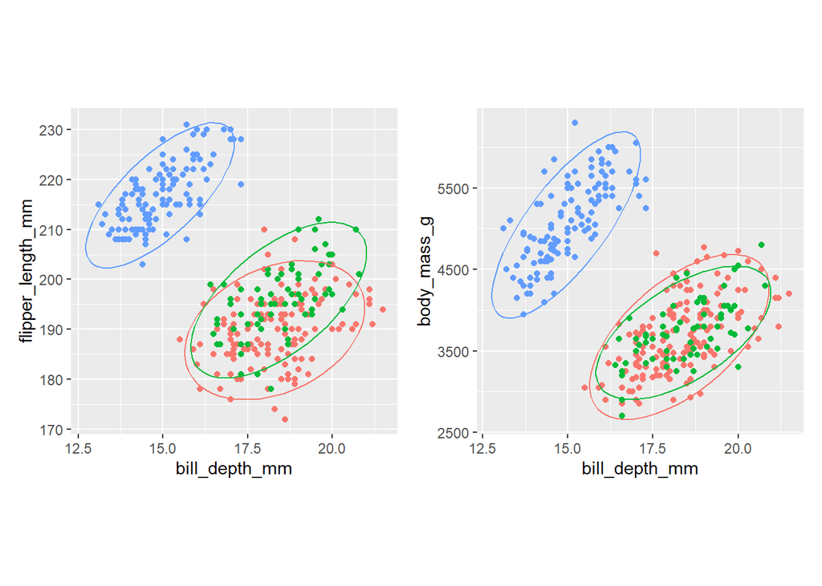

```r
p3 <- penguins |>
  ggplot(aes(x = bill_depth_mm, y = flipper_length_mm, group = species, color = species)) +
  geom_point() +
  stat_ellipse() +
  theme(aspect.ratio = 1, legend.position = "none")

p4 <- penguins |>
  ggplot(aes(x = bill_depth_mm, y = body_mass_g, group = species, color = species)) +
  geom_point() +
  stat_ellipse() +
  theme(aspect.ratio = 1, legend.position = "none")

p3 + p4
```

ペンギンの種類で分けると確かに正の相関になっているようですね。

このように「母集団での相関と、母集団を分割した集団での相関は、異なっている場合がある」、「集団を分けた場合にある仮説が成立しても、集団全体では正反対の仮説が成立することがある」という状態のことを[シンプソンのパラドクス](https://ja.wikipedia.org/wiki/%E3%82%B7%E3%83%B3%E3%83%97%E3%82%BD%E3%83%B3%E3%81%AE%E3%83%91%E3%83%A9%E3%83%89%E3%83%83%E3%82%AF%E3%82%B9)と呼びます。

この例は分かりやすいですが、実データでこれを発見するのは意外と大変で、統計的因果推論の入り口でもあります。

## 回帰モデル

次に回帰モデルを試してみましょう

体重を目的変数として、他のすべての変数を説明変数として投入します。

手法は線形回帰とランダムフォレスト、svmです。

```r
library(caret)
library(rsample)

df_split <- penguins |>
  mutate(year = factor(year)) |>
  drop_na() |>
  initial_split(strata = body_mass_g, prop = 0.8)

df_train <- df_split |> training()
df_test  <- df_split |> testing()

fit_lm <- train(body_mass_g ~ ., data = df_train, method = "lm")
fit_rf <- train(body_mass_g ~ ., data = df_train, method = "ranger")
fit_svm <- train(body_mass_g ~ ., data = df_train, method = "svmRadial")
```

できたモデルのあてはまりを正解との散布図で見てみます。

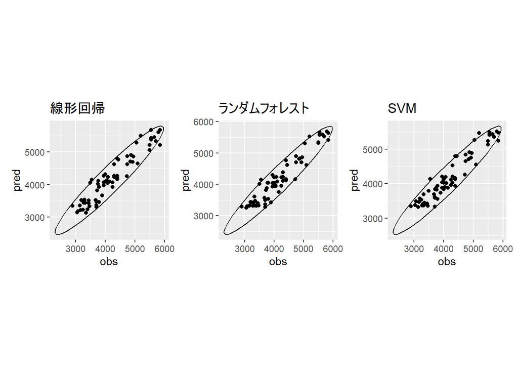

```r
pred_lm <- predict(fit_lm, newdata = df_test)
pred_rf <- predict(fit_rf, newdata = df_test)
pred_svm <- predict(fit_svm, newdata = df_test)

p1 <- data.frame(obs = df_test$body_mass_g, pred = pred_lm ) |>
  ggplot(aes(x = obs, y = pred)) +
  geom_point() +
  stat_ellipse() +
  labs(title = "線形回帰") +
  theme(aspect.ratio = 1)

p2 <- data.frame(obs = df_test$body_mass_g, pred = pred_rf ) |>
  ggplot(aes(x = obs, y = pred)) +
  geom_point() +
  stat_ellipse() +
  labs(title = "ランダムフォレスト") +
  theme(aspect.ratio = 1)

p3 <- data.frame(obs = df_test$body_mass_g, pred = pred_svm) |>
  ggplot(aes(x = obs, y = pred)) +
  geom_point() +
  stat_ellipse() +
  labs(title = "SVM") +
  theme(aspect.ratio = 1)

p1 + p2 + p3
```

いずれも悪くない当てはまりに見えます。

モデルの当てはまり具合を定量的に確かめてみましょう。

評価指標としてRMSE（二乗平均平方誤差、Root Mean Squared Error）とMAPE（平均絶対パーセント誤差、Mean Absolute Percentage Error）を使いましょう。

```r
library(yardstick)

data.frame(
  手法 = c("lm", "rf", "svm"),
  MAPE = c(
    mape_vec(pred_lm, df_test$body_mass_g),
    mape_vec(pred_rf, df_test$body_mass_g),
    mape_vec(pred_svm, df_test$body_mass_g)
    ) |>
    round(3),
  RMSE = c(
    rmse_vec(pred_lm, df_test$body_mass_g),
    rmse_vec(pred_rf, df_test$body_mass_g),
    rmse_vec(pred_svm, df_test$body_mass_g)
    ) |>
    round(2)
  )
```

| 手法 | MAPE | RMSE |
| --- | --- | --- |
| lm | 5.067 | 255.50 |
| rf | 4.810 | 241.22 |
| svm | 5.101 | 256.80 |

定量的にみてもほとんど変わらないようです。

## 判別モデル

お次は判別モデルです。

ペンギンの種類を判別する多クラス分類というやつです。

説明変数としてflipper_length_mmとbill_depth_mmの二つを使います。

手法として線形判別分析(lda)、二次判別分析(qda)、SVM、決定木(cart)、ランダムフォレスト(rf)を試してみます。

正解はこんな感じ。ちょっと意地悪ですね。

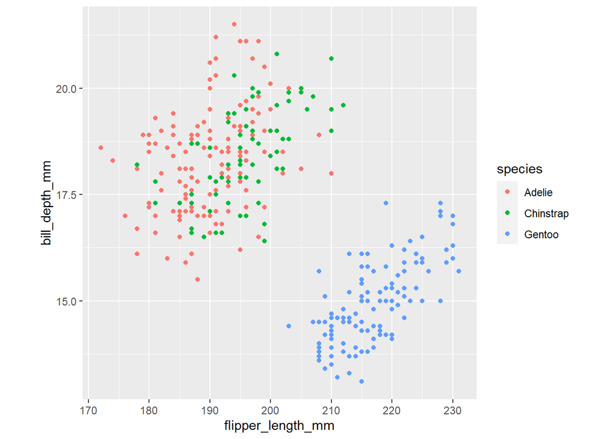

```r
penguins |>
  dplyr::select(flipper_length_mm, bill_depth_mm, species) |>
  drop_na() |>
  ggplot(aes(x = flipper_length_mm, y = bill_depth_mm, color = species)) +
  geom_point() +
  theme(aspect.ratio = 1)
```

ではモデルを作ります。

```r
set.seed(0)

df_split <- penguins |>
  dplyr::select(flipper_length_mm, bill_depth_mm, species) |>
  drop_na() |>
  initial_split(strata = species, prop = 0.8)

df_train <- df_split |>
  training()

df_test <- df_split |>
  testing()

fit_lda   <- train(species ~ flipper_length_mm + bill_depth_mm, data = df_train, method = "lda")
fit_qda   <- train(species ~ flipper_length_mm + bill_depth_mm, data = df_train, method = "qda")
fit_svm   <- train(species ~ flipper_length_mm + bill_depth_mm, data = df_train, method = "svmRadial")
fit_rpart <- train(species ~ flipper_length_mm + bill_depth_mm, data = df_train, method = "rpart")
fit_rf    <- train(species ~ flipper_length_mm + bill_depth_mm, data = df_train, method = "ranger")
```

評価指標で当てはまりを確認してみましょう。

```r
pred_lda   <- predict(fit_lda, newdata = df_test)
pred_qda   <- predict(fit_qda, newdata = df_test)
pred_svm   <- predict(fit_svm, newdata = df_test)
pred_rpart <- predict(fit_rpart, newdata = df_test)
pred_rf    <- predict(fit_rf, newdata = df_test)

data.frame(
  手法 = c("lda", "qda", "svm", "rpart", "rf"),
  Accuracy = c(
    accuracy_vec(pred_lda, df_test$species),
    accuracy_vec(pred_qda, df_test$species),
    accuracy_vec(pred_svm, df_test$species),
    accuracy_vec(pred_rpart, df_test$species),
    accuracy_vec(pred_rf, df_test$species)
    ) |>
    round(3),
  F1_score = c(
    f_meas_vec(pred_lda, df_test$species),
    f_meas_vec(pred_qda, df_test$species),
    f_meas_vec(pred_svm, df_test$species),
    f_meas_vec(pred_rpart, df_test$species),
    f_meas_vec(pred_rf, df_test$species)
    ) |>
    round(3)
  )
```

[output not shown]

ランダムフォレストが意外と低いですね。

## 描画関数

視覚的にも確認してみましょう。

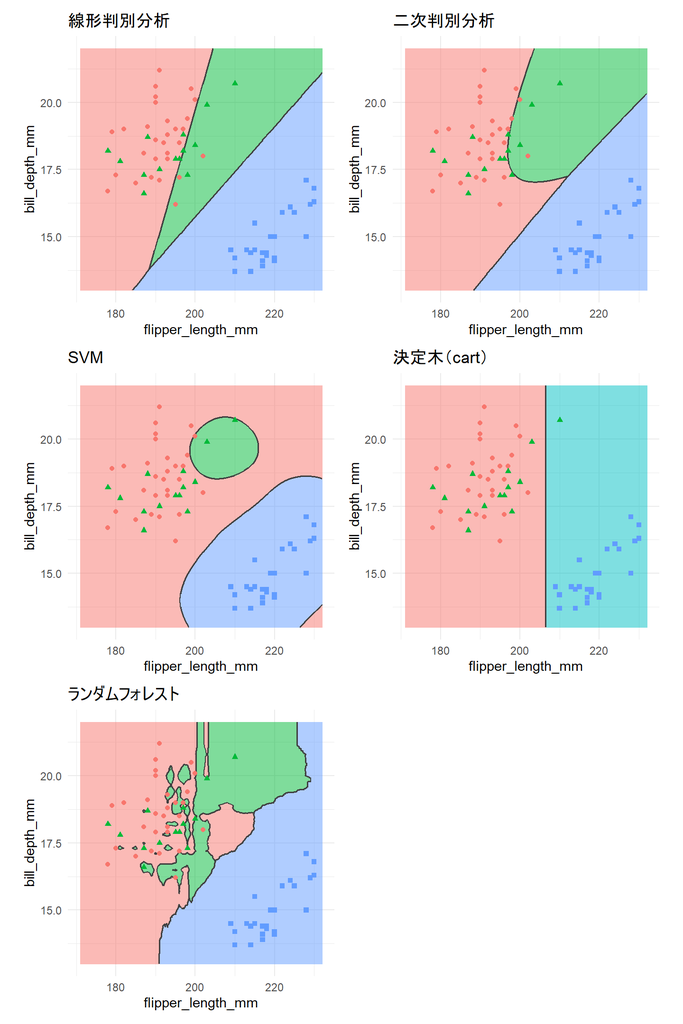

```r
pen_plot <- function(fit, data, title) {
  resolution <- 500
  base_df <-expand.grid(
    flipper_length_mm = seq(171, 232, length.out = resolution),
    bill_depth_mm = seq(13, 22, length.out = resolution)
    )

base_df |>
  mutate(pred = predict(fit, newdata = base_df)) |>
  ggplot(aes(x = flipper_length_mm, y = bill_depth_mm)) +
  geom_raster(aes(fill = pred), alpha = 0.5) +
  geom_contour(aes(z = as.numeric(pred)), color = "gray25") +
  geom_point(data = data, aes(x = flipper_length_mm, y = bill_depth_mm, shape = species, color = species)) +
  theme_minimal() +
  theme(legend.position = "none", aspect.ratio = 1) +
  labs(title = title)
}

p1 <- pen_plot(fit_lda, df_test, "線形判別分析")
p2 <- pen_plot(fit_qda, df_test, "二次判別分析")
p3 <- pen_plot(fit_svm, df_test, "SVM")
p4 <- pen_plot(fit_rpart, df_test, "決定木（cart）")
p5 <- pen_plot(fit_rf, df_test, "ランダムフォレスト")

p1 + p2 + p3 + p4 + p5 + plot_layout(ncol = 2)
```

決定木はアンダーフィット、ランダムフォレストはオーバーフィットな感じですね。

## 次元縮約（次元削減）

次に次元削減を試してみましょう。

bill_length_mm、bill_depth_mm、flipper_length_mm、body_mass_gの4つ変数を2次元にまとめましょう。

手法は主成分分析、因子分析、t-SNE、UMAPです。

```r
library(psych)
library(Rtsne)
library(umap)

df <- penguins |>
  dplyr::select(!c(island, sex, year)) |>
  drop_na()

df_std <- df |>
  dplyr::select(!species) |>
  mutate(across(everything(), scale))

scores_pca <- df_std |>
  principal(nfactors = 2, rotate = "none") |>
  pluck("scores") |>
  as.data.frame()

scores_fa <- df_std |>
  fa(nfactors = 2, rotate = "promax", fm = "ml") |>
  pluck("scores") |>
  as.data.frame()
```

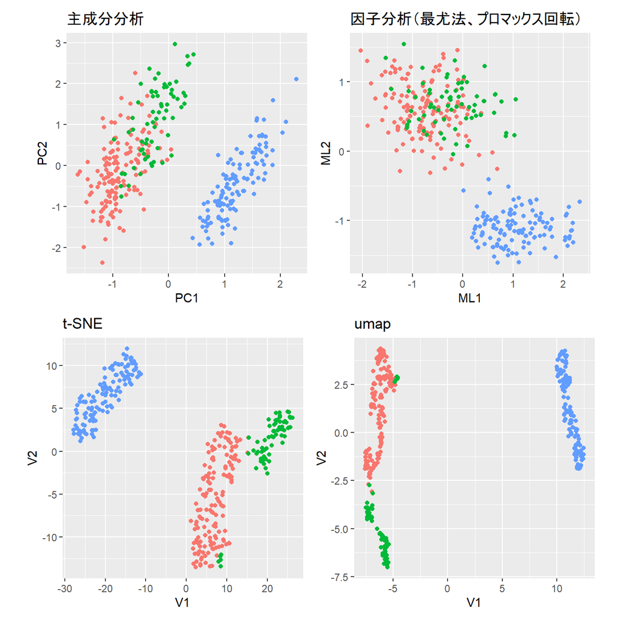

```r
scores_tsne <- df_std |>
  as.matrix() |>
  Rtsne(pca = FALSE) |>
  pluck("Y") |>
  as.data.frame()

scores_umap <- df_std |>
  as.matrix() |>
  umap() |>
  pluck("layout") |>
  as.data.frame()

p1 <- scores_pca |>
  mutate(species = df$species) |>
  ggplot(aes(x = PC1, y = PC2, color = species)) +
  geom_point() +
  labs(title = "主成分分析") +
  theme(aspect.ratio = 1, legend.position = "none")

p2 <- scores_fa |>
  mutate(species = df$species) |>
  ggplot(aes(x = ML1, y = ML2, color = species)) +
  geom_point() +
  labs(title = "因子分析（最尤法、プロマックス回転）") +
  theme(aspect.ratio = 1, legend.position = "none")

p3 <- scores_tsne |>
  mutate(species = df$species) |>
  ggplot(aes(x = V1, y = V2, color = species)) +
  geom_point() +
  labs(title = "t-SNE") +
  theme(aspect.ratio = 1, legend.position = "none")

p4 <- scores_umap |>
  mutate(species = df$species) |>
  ggplot(aes(x = V1, y = V2, color = species)) +
  geom_point() +
  labs(title = "umap") +
  theme(aspect.ratio = 1, legend.position = "none")

{p1|p2}/{p3|p4}
```

それぞれの手法の特徴がよく表れていますね。

## クラスタリング

最後にクラスタリングです。

主成分得点を使って、以下の各手法でクラスタリングをしてみます。

- 階層型
  - ウォード法
  - 群平均法（UPGMA）
    - ユークリッド距離
    - マンハッタン距離
- k-means
- k-medoids(Partitioning Around Medoids, PAM)
- 混合正規分布モデル (Gaussian Mixture Model, GMM)

```r
library(cluster)
library(mclust)
res <- tibble(
  PC1 = scores_pca$PC1,
  PC2 = scores_pca$PC2,
  正解 = as.numeric(df$species),
  階層型ウォード法 = scores_pca |>
    dist() |>
    hclust(method = "ward.D2") |>
    cutree(3),
 階層型群平均法ユークリッド距離 = scores_pca |>
   dist() |>
   hclust(method = "average") |>
   cutree(3),
 階層型群平均法マンハッタン距離 = scores_pca |>
   dist(method = "manhattan") |>
   hclust(method = "average") |>
   cutree(3),
 `k-means法` = scores_pca |>
   kmeans(3) |>
   pluck("cluster"),
 `k-medoids法(pam)` = scores_pca |>
   pam(3) |>
   pluck("clustering"),
 混合正規分布モデル = scores_pca |>
   Mclust(G = 3) |>
   pluck("classification")
 )
```

結果を可視化してみましょう。

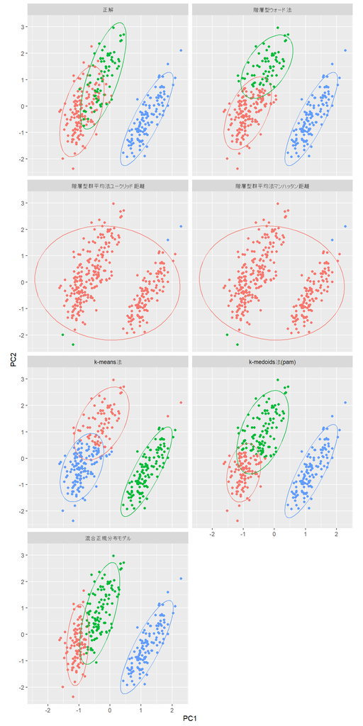

```r
res |>
  pivot_longer(!c(PC1, PC2), names_to = "method", values_to = "clust") |>
  mutate(
    clust = factor(clust),
    method = factor(
      method,
      levels = c(
        "正解", "階層型ウォード法", "階層型群平均法ユークリッド距離", "階層型群平均法マンハッタン距離",
        "k-means法", "k-medoids法(pam)", "混合正規分布モデル"))
    ) |>
  ggplot(aes(x = PC1, y = PC2, color = clust)) +
  geom_point() +
  stat_ellipse() +
  facet_wrap(vars(method), ncol = 2) +
  theme(aspect.ratio = 1, legend.position = "none")
```

混合正規分布モデルがなかなかいいですね！

以上です。

ペンギンデータ、なかなか面白いでしょ？